# 模糊 C 平均 (Fuzzy C-Means)

JianKai Wang (https://sophia.ddns.net/)

2018年4月11日

非監督式學習是機器學習中重要的一支，也是目前機器學習中發展核心，其中一議題便是分群(clustering)，將大量資料經機器透過一些規則自我形成一群聚。常見的分群演算法，如 k-means, SOM 等為硬分群 (hard partitions, hard clustering)，一筆資料只會被分配到單一群聚中，在資料具代表性且資料量多時，硬分群是效果佳的演算法；但在實務上，資料蒐集本身可能就是問題，甚至是需經長時間來收集不同樣態特徵的樣本，此時硬分群的結果就不盡人意。此外，資料中多有不同樣態的雜訊(noise)，硬分群在資料前處理不佳下，很容易受到雜訊的影響，也會對分群的結果大打折扣。針對資料蒐集、資料樣態或雜訊處理等議題，軟分群(soft clustering)的概念就被提出，其中最有名的就是模糊 C 平均(Fuzzy C-Means, FCM)演算法，最早由 J.C. Dunn 於 1973 提出，經 James C.Bezdek 進行優化。軟分群不同於硬分群有底下數點

- 能說明該分群結果有多少程度能代表該資料
- 能說明資料有多少程度屬於該分群，又有多少程度屬於另一分群
- 對於雜訊具有較佳的容忍度

Fuzzy C-means 演算法與 k-means 相似，不同於允許資料不同程度上屬於多個群聚，而 FCM 要解決的問題是最小化加權後平方誤差(minimization of a weighted square error function)，即最小化底下的目標函式

$$J_m = \sum_{i=1}^{N}\sum_{j=1}^{C}u_{ij}^m||x_i-c_j||^2\ ,\ 1 \leq m < \infty$$

其中 $m \geq 1$，$u_{ij}$ 代表資料 $X_i$ 屬於分群 $j$ 的程度(degree of membership), $x_i$ 是資料 $x$ 全部 $d$ 維度中第 $i$ 維的資料，$c_j$ 表示群集的中心(亦有 $d$ 維度資料)，$||*||$ 表示資料與中心點間的相似度。而模糊分群法是一反覆計算最佳化目標函式的過程，並不斷更新成員程度($u_{ij}$)與中心點 $c_j$，如下

$$u_{ij} = \frac{1}{\sum_{k=1}^{C}(\frac{||x_i-c_j||}{||x_i-c_k||})^{(\frac{2}{m-1})}}, \\
c_j = \frac{\sum_{i=1}^Nu_{ij}^m*x_i}{\sum_{i=1}^Nu_{ij}^m}$$

而反覆計算停止的條件為當 $max_{ij}\{\|u_{ij}^{(k+1)}-u_{ij}^{(k)}|\} < \varepsilon$，而 $\varepsilon$ 為介於 0 至 1 的終止條件，而 $k$ 為反覆的步驟，這過程會收斂於目標函式 $J_m$ 的區域最小值(local minimum)或鞍點(saddle point)。

FCM 演算法如下:

1. 初始化 $U^{(0)}=[u_{ij}]$ 矩陣
2. 在第 k 步驟時，計算中心點的特徵向量 $C^{(k)}=[c_j]$，$c_j$ 計算請參考上述
3. 更新 $U^{(k)}$ 及 $U^{(k+1)}$ 矩陣
4. 若 $||U^{(k+1)}-U^{(k)}|| < \varepsilon$，則停止；否則重覆 2-4 步驟

FCM 最常用於模式判斷，如時間序列資料等。

## R 實作

### 安裝套件

```r
packageName <- c("e1071")
for(i in 1:length(packageName)) {
  if(!(packageName[i] %in% rownames(installed.packages()))) {
    install.packages(packageName[i])
  }
}
library("e1071")
library("Mfuzz")
```

### 資料準備

底下透過套件內建的酵母菌細胞週期分子資料來實作軟分群演算法。此酵母菌細胞週期分子資料收集 6178 個基因於 160 分鐘內的 17 個時間點的表現資料，並經過整理後列出 3000 個基因於 17 個時間點的表現資料。

```r
data(yeast)
str(yeast)
```

```
## Formal class 'ExpressionSet' [package "Biobase"] with 7 slots
##   ..@ experimentData   :Formal class 'MIAME' [package "Biobase"] with 13 slots
##   .. .. ..@ name             : chr ""
##   .. .. ..@ lab              : chr ""
##   .. .. ..@ contact          : chr ""
##   .. .. ..@ title            : chr ""
##   .. .. ..@ abstract         : chr ""
##   .. .. ..@ url              : chr ""
##   .. .. ..@ pubMedIds        : chr ""
##   .. .. ..@ samples          : list()
##   .. .. ..@ hybridizations   : list()
##   .. .. ..@ normControls     : list()
##   .. .. ..@ preprocessing    : list()
##   .. .. ..@ other            : list()
##   .. .. ..@ .__classVersion__:Formal class 'Versions' [package "Biobase"] with 1 slot
##   .. .. .. .. ..@ .Data:List of 1
##   .. .. .. .. .. ..$ : int [1:3] 1 0 0
##   ..@ assayData        :<environment: 0x00000000178b4bd0>
##   ..@ phenoData        :Formal class 'AnnotatedDataFrame' [package "Biobase"] with 4 slots
##   .. .. ..@ varMetadata      :'data.frame':  3 obs. of  1 variable:
##   .. .. .. ..$ labelDescription: chr [1:3] "NULL" "NULL" "NULL"
##   .. .. ..@ data             :'data.frame':  17 obs. of  3 variables:
##   .. .. .. ..$ index: int [1:17] 0 1 2 3 4 5 6 7 8 9 ...
##   .. .. .. ..$ label: Factor w/ 17 levels "cdc28_0","cdc28_10",..: 1 2 10 11 12 13 14 15 16 17 ...
##   .. .. .. ..$ time : num [1:17] 0 10 20 30 40 50 60 70 80 90 ...
##   .. .. ..@ dimLabels        : chr [1:2] "sampleNames" "sampleColumns"
##   .. .. ..@ .__classVersion__:Formal class 'Versions' [package "Biobase"] with 1 slot
##   .. .. .. .. ..@ .Data:List of 1
##   .. .. .. .. .. ..$ : int [1:3] 1 1 0
##   ..@ featureData      :Formal class 'AnnotatedDataFrame' [package "Biobase"] with 4 slots
##   .. .. ..@ varMetadata      :'data.frame':  0 obs. of  1 variable:
##   .. .. .. ..$ labelDescription: chr(0)
##   .. .. ..@ data             :'data.frame':  3000 obs. of  0 variables
##   .. .. ..@ dimLabels        : chr [1:2] "featureNames" "featureColumsn"
##   .. .. ..@ .__classVersion__:Formal class 'Versions' [package "Biobase"] with 1 slot
##   .. .. .. .. ..@ .Data:List of 1
##   .. .. .. .. .. ..$ : int [1:3] 1 1 0
##   ..@ annotation       : chr [1:6178] "YAL001C" "YAL002W" "YAL003W" "YAL004W" ...
##   ..@ protocolData     :Formal class 'AnnotatedDataFrame' [package "Biobase"] with 4 slots
##   .. .. ..@ varMetadata      :'data.frame':  0 obs. of  1 variable:
##   .. .. .. ..$ labelDescription: chr(0)
##   .. .. ..@ data             :'data.frame':  17 obs. of  0 variables
##   .. .. ..@ dimLabels        : chr [1:2] "sampleNames" "sampleColumns"
##   .. .. ..@ .__classVersion__:Formal class 'Versions' [package "Biobase"] with 1 slot
##   .. .. .. .. ..@ .Data:List of 1
##   .. .. .. .. .. ..$ : int [1:3] 1 1 0
##   ..@ .__classVersion__:Formal class 'Versions' [package "Biobase"] with 1 slot
##   .. .. ..@ .Data:List of 4
##   .. .. .. ..$ : int [1:3] 2 10 0
##   .. .. .. ..$ : int [1:3] 2 5 5
##   .. .. .. ..$ : int [1:3] 1 3 0
##   .. .. .. ..$ : int [1:3] 1 0 0
```

此資料是使用 microchip (Affymetrix chips) 產出，包含如分析資料(assayData), 表現資料 (phenoData), 註解資料 (annotation), 與使用的 protocol (protocolData)等內容。

- 每個基因的表現資料

其中 cdc28_0, cdc28_10, … , cdc28_160 代表 17 個時間的標籤。可以透過 `yeast$time` 來取得時間(單位分鐘)。

```r
# 3000 (genes) x 17 (time points)
head(yeast@assayData[["exprs"]], 10)
```

```
##           cdc28_0 cdc28_10 cdc28_20 cdc28_30 cdc28_40 cdc28_50 cdc28_60
## YDR132C      0.19     0.30    -0.29     0.29    -0.31     0.23     0.20
## YMR012W     -0.15    -0.15    -0.04    -0.28    -0.39     0.03     0.22
## YLR214W      0.38     0.30    -0.68    -0.52    -0.43    -0.13    -0.17
## YLR116W      0.17     0.06    -0.21     0.19     0.33     0.44     0.46
## YDR203W      0.85    -0.10    -0.56    -0.31    -0.43     0.00    -0.34
## YEL059C-A    0.45     0.20     0.06     0.10    -0.21    -0.08    -0.27
## YHR046C      0.37     0.31     0.07    -0.14    -0.69    -0.10     0.21
## YJL053W      0.38    -0.14    -0.14     0.17    -0.21     0.04    -0.06
## YBL021C     -0.25    -0.09     0.34    -0.01     0.16    -0.11    -0.22
## YHR034C      0.89    -0.02    -0.22     0.02     0.17     0.37     0.15
##           cdc28_70 cdc28_80 cdc28_90 cdc28_100 cdc28_110 cdc28_120
## YDR132C      -0.08     0.19    -0.51      0.00     -0.31      0.11
## YMR012W       0.04    -0.15     0.37      0.47     -0.10     -0.09
## YLR214W       0.26    -0.03    -0.34     -0.01     -0.20      0.10
## YLR116W       0.38    -0.15    -0.03      0.04     -0.42     -0.15
## YDR203W       0.17     0.40    -0.37      0.15      0.24      0.24
## YEL059C-A    -0.01    -0.29     0.41     -0.08     -0.22     -0.27
## YHR046C       0.05     0.24    -0.16     -0.18     -0.09      0.16
## YJL053W       0.07     0.00    -0.23      0.07     -0.01      0.12
## YBL021C       0.02    -0.22    -0.09     -0.01      0.04     -0.02
## YHR034C       0.17     0.04    -0.15     -0.40     -0.15     -0.02
##           cdc28_130 cdc28_140 cdc28_150 cdc28_160
## YDR132C       -0.02      0.20      0.36     -0.54
## YMR012W          NA     -0.04      0.07      0.19
## YLR214W          NA      0.45      0.40      0.63
## YLR116W        0.02        NA     -0.51     -0.61
## YDR203W        0.17     -0.12     -0.02      0.02
## YEL059C-A        NA     -0.30      0.25      0.26
## YHR046C       -0.10      0.05        NA        NA
## YJL053W          NA     -0.04     -0.14      0.12
## YBL021C          NA      0.01      0.27      0.17
## YHR034C        0.04     -0.23     -0.38     -0.27
```

### 資料製作

mfuzz 使用類別 **ExpressionSet** 產出的物件，若為自己的資料，可以透過套件 **Biobase** 來產生物件。相關內容可以參考 https://www.bioconductor.org/packages/3.7/bioc/vignettes/Biobase/inst/doc/ExpressionSetIntroduction.pdf。

```r
library("Biobase")
```

ExpressionSet 物件主要包含 3 個屬性，分別為 **assayData**, **phenoData**, **featureData**，其中最小資料集至少需包含 **assayData** 屬性。

- 產生最小分析用的資料集

```r
set.seed(123)

# 產生模擬資料
miniDataSet <- matrix(cbind(
  rnorm(1000, mean = 0, sd = 2),
  rnorm(1000, mean = 100, sd = 10),
  rnorm(1000, mean = 20, sd = 5),
  rnorm(1000, mean = 10, sd = 10)
), ncol=4)
colnames(miniDataSet) <- c("feat1","feat2","feat3","feat4")
rownames(miniDataSet) <- paste(rep("data_",1000),seq(1,1000,1),sep="")
head(miniDataSet, 5)
```

```
##             feat1    feat2    feat3     feat4
## data_1 -1.1209513 90.04201 17.44198  8.496925
## data_2 -0.4603550 89.60045 21.18469  6.722429
## data_3  3.1174166 99.82020 17.29205 -4.481653
## data_4  0.1410168 98.67825 26.09614  3.027154
## data_5  0.2585755 74.50657 20.87068 35.984902
```

```r
# 產生最小資料集
miniDataSet.expset <- ExpressionSet(assayData = miniDataSet)
```

- 準備完整分析的資料集

assayData 為記錄特徵值的表，phenoData 為記錄特徵為何模式或處理(`準備資料時須注意 phenoData 的列名需與 assayData 的行名相同`)，featureData 為紀錄每筆資料的對應資訊或真實資訊等(`準備資料時須注意 featureData 的列名需與 assayData 的列名相同`)。需要注意 phenoData 與 featureData 需經過函式 **AnnotatedDataFrame** 將資料進行轉換並記錄 meta data 等屬性。

```r
# 準備 assayData, 參考上述產生最小分析用的資料集
full.assayData <- miniDataSet
head(full.assayData, 5)
```

```
##             feat1    feat2    feat3     feat4
## data_1 -1.1209513 90.04201 17.44198  8.496925
## data_2 -0.4603550 89.60045 21.18469  6.722429
## data_3  3.1174166 99.82020 17.29205 -4.481653
## data_4  0.1410168 98.67825 26.09614  3.027154
## data_5  0.2585755 74.50657 20.87068 35.984902
```

```r
# 準備 phenoData
full.phenoData <- as.data.frame(rbind(
  c("control","1"),
  c("control","2"),
  c("test","1"),
  c("test","2")
))
colnames(full.phenoData) <- c("treatment","sequence")
rownames(full.phenoData) <- colnames(miniDataSet)
full.phenoData.annot <- AnnotatedDataFrame(full.phenoData)
head(full.phenoData, 5)
```

```
##       treatment sequence
## feat1   control        1
## feat2   control        2
## feat3      test        1
## feat4      test        2
```

```r
# 準備 featureData
tureRowNames <- paste(rep("species_",1000),seq(1,1000,1),sep="")
full.featureData <- as.data.frame(tureRowNames, ncol=1)
colnames(full.featureData) <- c("symbol")
rownames(full.featureData) <- rownames(miniDataSet)
full.featureData.annot <- AnnotatedDataFrame(full.featureData)
head(full.featureData, 5)
```

```
##           symbol
## data_1 species_1
## data_2 species_2
## data_3 species_3
## data_4 species_4
## data_5 species_5
```

```r
# 產生完整的 ExpressionSet 物件
fullDataSet.expset <- ExpressionSet(assayData = full.assayData, phenoData = full.phenoData.annot, featureData = full.featureData.annot)
```

當準備好資料結構後便可以接續下方的分析。

### 資料前處理

- 移除含有過有 NA 的資料

```r
# the prototype of filter.NA
# eset: 由類別 ExpressionSet 產生的物件
filter.NA(eset,thres=0.25)
```

```r
# 移除含有超過 25% NA 的資料
yeast.filter.na <- filter.NA(yeast, thres = 0.25)
```

```
## 49 genes excluded.
```

- 對 NA 填值

FCM 與其他許多分群演算法相同，不允許 NA 的存在，需要透過填值方式處理 NA。

```r
# the prototype of fill.NA
# eset: 由類別 ExpressionSet 產生的物件
# mode: 填值計算方法，包含有 mean, median, knn (需填後續的 k 值), knnw (需填後續的 k 值) 等
# |- knnw: 與 knn 相同，但加入與資料的距離作為加權數
# k: 若模式選擇 knn, knnw 時需指派有多少個鄰近值
fill.NA(eset,mode="mean",k=10)
```

```r
yeast.fill.na <- fill.NA(yeast.filter.na, mode = "mean")
head(yeast.fill.na@assayData[["exprs"]], 10)
```

```
##           cdc28_0 cdc28_10 cdc28_20 cdc28_30 cdc28_40 cdc28_50 cdc28_60
## YDR132C      0.19     0.30    -0.29     0.29    -0.31     0.23     0.20
## YMR012W     -0.15    -0.15    -0.04    -0.28    -0.39     0.03     0.22
## YLR214W      0.38     0.30    -0.68    -0.52    -0.43    -0.13    -0.17
## YLR116W      0.17     0.06    -0.21     0.19     0.33     0.44     0.46
## YDR203W      0.85    -0.10    -0.56    -0.31    -0.43     0.00    -0.34
## YEL059C-A    0.45     0.20     0.06     0.10    -0.21    -0.08    -0.27
## YHR046C      0.37     0.31     0.07    -0.14    -0.69    -0.10     0.21
## YJL053W      0.38    -0.14    -0.14     0.17    -0.21     0.04    -0.06
## YBL021C     -0.25    -0.09     0.34    -0.01     0.16    -0.11    -0.22
## YHR034C      0.89    -0.02    -0.22     0.02     0.17     0.37     0.15
##           cdc28_70 cdc28_80 cdc28_90 cdc28_100 cdc28_110 cdc28_120
## YDR132C      -0.08     0.19    -0.51      0.00     -0.31      0.11
## YMR012W       0.04    -0.15     0.37      0.47     -0.10     -0.09
## YLR214W       0.26    -0.03    -0.34     -0.01     -0.20      0.10
## YLR116W       0.38    -0.15    -0.03      0.04     -0.42     -0.15
## YDR203W       0.17     0.40    -0.37      0.15      0.24      0.24
## YEL059C-A    -0.01    -0.29     0.41     -0.08     -0.22     -0.27
## YHR046C       0.05     0.24    -0.16     -0.18     -0.09      0.16
## YJL053W       0.07     0.00    -0.23      0.07     -0.01      0.12
## YBL021C       0.02    -0.22    -0.09     -0.01      0.04     -0.02
## YHR034C       0.17     0.04    -0.15     -0.40     -0.15     -0.02
##               cdc28_130 cdc28_140     cdc28_150     cdc28_160
## YDR132C   -2.000000e-02  0.200000  3.600000e-01 -5.400000e-01
## YMR012W   -3.035766e-18 -0.040000  7.000000e-02  1.900000e-01
## YLR214W    6.250000e-04  0.450000  4.000000e-01  6.300000e-01
## YLR116W    2.000000e-02  0.000625 -5.100000e-01 -6.100000e-01
## YDR203W    1.700000e-01 -0.120000 -2.000000e-02  2.000000e-02
## YEL059C-A  5.421011e-19 -0.300000  2.500000e-01  2.600000e-01
## YHR046C   -1.000000e-01  0.050000  1.851727e-18  1.851727e-18
## YJL053W   -1.192622e-18 -0.040000 -1.400000e-01  1.200000e-01
## YBL021C   -6.250000e-04  0.010000  2.700000e-01  1.700000e-01
## YHR034C    4.000000e-02 -0.230000 -3.800000e-01 -2.700000e-01
```

- 資料過濾

許多分群工具皆有提供資料過濾步驟來移除變異低的資料(如小變化的基因表現等)，目的為挑出資料變異較大的資料供後續分析。

```r
yeast.filter.trim <- filter.std(yeast.fill.na, min.std = 0)
```

```
## 0 genes excluded.
```

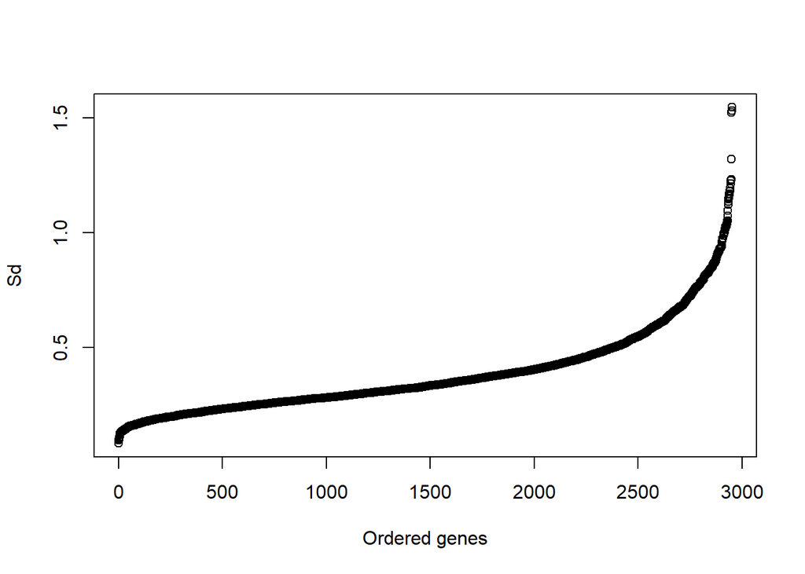

- 資料標準化 (Standardisation)

因分群的距離計算是在 Euclidian 空間中，資料的特徵值(如基因的表現值)需要經過標準化處理使之相同樣本下的資料平均值為 0 及相對於 1 個標準差的對比值，促使可以讓樣本間來比較。

```r
yeast.std <- standardise(yeast.filter.trim)
head(yeast.std@assayData[["exprs"]], 10)
```

```
##              cdc28_0    cdc28_10   cdc28_20    cdc28_30   cdc28_40
## YDR132C    0.6507079  1.02860350 -0.9982910  0.99424935 -1.0669993
## YMR012W   -0.6842079 -0.68420789 -0.1824554 -1.27718807 -1.7789405
## YLR214W    1.0250819  0.80891968 -1.8390679 -1.40674342 -1.1635609
## YLR116W    0.5310348  0.18615610 -0.6603643  0.59373997  1.0326765
## YDR203W    2.4362918 -0.28473950 -1.6022915 -0.88623064 -1.2299399
## YEL059C-A  1.8186458  0.80828701  0.2424861  0.40414350 -0.8487014
## YHR046C    1.5168521  1.27087610  0.2869720 -0.57394404 -2.8287242
## YJL053W    2.4834745 -0.91496428 -0.9149643  1.11102806 -1.3724464
## YBL021C   -1.5153805 -0.54310629  2.0698806 -0.05696919  0.9760721
## YHR034C    2.8693556 -0.06642027 -0.7116457  0.06262483  0.5465439
##               cdc28_50   cdc28_60    cdc28_70      cdc28_80    cdc28_90
## YDR132C    0.788124487  0.6850621 -0.27685399  6.507079e-01 -1.75408219
## YMR012W    0.136841579  1.0035049  0.18245544 -6.842079e-01  1.68771281
## YLR214W   -0.352952430 -0.4610336  0.70083856 -8.274961e-02 -0.92037835
## YLR116W    1.377555122  1.4402603  1.18943949 -4.722486e-01 -0.09601736
## YDR203W    0.001684849 -0.9721579  0.48860624  1.147382e+00 -1.05808525
## YEL059C-A -0.323314804 -1.0911875 -0.04041435 -1.172016e+00  1.65698837
## YHR046C   -0.409960031  0.8609161  0.20498002  9.839041e-01 -0.65593605
## YJL053W    0.261418366 -0.3921275  0.45748214  7.794335e-18 -1.50315561
## YBL021C   -0.664640567 -1.3330791  0.12533222 -1.333079e+00 -0.54310629
## YHR034C    1.191769402  0.4820214  0.54654393  1.271474e-01 -0.48581683
##              cdc28_100   cdc28_110   cdc28_120   cdc28_130   cdc28_140
## YDR132C   -0.002020832 -1.06699931  0.37587476 -0.07072912  0.68506205
## YMR012W    2.143851401 -0.45613860 -0.41052474  0.00000000 -0.18245544
## YLR214W   -0.028709049 -0.54209440  0.26851405  0.00000000  1.21422391
## YLR116W    0.123450886 -1.31876899 -0.47224863  0.06074567  0.00000000
## YDR203W    0.431321374  0.68910329  0.68910329  0.48860624 -0.34202437
## YEL059C-A -0.323314804 -0.88911571 -1.09118746  0.00000000 -1.21243051
## YHR046C   -0.737928056 -0.36896403  0.65593605 -0.40996003  0.20498002
## YJL053W    0.457482141 -0.06535459  0.78425510  0.00000000 -0.26141837
## YBL021C   -0.056969191  0.24686650 -0.11773633  0.00000000  0.06456508
## YHR034C   -1.292348667 -0.48581683 -0.06642027  0.12714737 -0.74390702
##               cdc28_150     cdc28_160
## YDR132C    1.234728e+00 -1.857145e+00
## YMR012W    3.192970e-01  8.666633e-01
## YLR214W    1.079123e+00  1.700589e+00
## YLR116W   -1.600942e+00 -1.914468e+00
## YDR203W   -5.560002e-02  5.896972e-02
## YEL059C-A  1.010359e+00  1.050773e+00
## YHR046C   -5.767468e-22 -5.767468e-22
## YJL053W   -9.149643e-01  7.842551e-01
## YBL021C    1.644511e+00  1.036839e+00
## YHR034C   -1.227826e+00 -8.729521e-01
```

需要注意的是，標準化(Standardisation)與正規化(Normalisation)並不相同，標準化目的使資料間(如基因間)可以比較，正規化目的使樣本間(如時間點間)可以比較。

### 建立 FCM 模型

```r
# the prototype of mfuzz
# eset: 類別 ExpressionSet 的物件
# centers: 分群數目
# m: 模糊化參數
mfuzz(eset, centers, m)
```

```r
yeast.fcm <- mfuzz(yeast.std, centers = 16, m = 1.25)
summary(yeast.fcm)
```

```
##             Length Class  Mode
## centers       272  -none- numeric
## size           16  -none- numeric
## cluster      2951  -none- numeric
## membership  47216  -none- numeric
## iter            1  -none- numeric
## withinerror     1  -none- numeric
## call            5  -none- call
```

### FCM 結果

- 顯示各分群中心

```r
yeast.fcm$centers
```

```
##       cdc28_0   cdc28_10    cdc28_20    cdc28_30    cdc28_40    cdc28_50
## 1  -0.8191853 -1.1585300 -1.33535349 -0.17894616  0.51924541  0.72642676
## 2   0.3496005  0.4112077  0.45338229  0.73760093  0.69739062  0.49657820
## 3  -1.0292662  0.4315193  0.65516601  0.04000151 -0.11010745 -0.29183382
## 4  -0.4318914 -0.1183012  1.41365258  0.84785538  0.02116613 -0.28289756
## 5  -1.7051179 -0.6540063 -0.52103457 -0.41646787  0.05008171 -0.18260465
## 6  -1.2280581 -1.0134957  0.02129761  0.63851835  0.83781937  0.63174320
## 7   0.7382132  0.1156997 -0.51019951 -0.75668056 -1.11784917 -0.77539506
## 8  -0.8025271 -0.5454651  0.25905375 -0.20192735  0.02064164 -1.02932210
## 9   1.1279009 -0.4812007 -1.44698429 -0.61142731 -0.45204208 -0.10895502
## 10  0.5492421  0.4632392 -0.10371295  0.13173940  0.07475805  0.30093595
## 11 -1.1861986  0.7523508  0.62368794  0.33792580  0.51740675  0.32070628
## 12 -0.3058531 -1.2363419 -1.55812759 -0.76918882 -0.12748589 -0.02790586
## 13  1.7726572  0.9228351  0.28100744 -0.06793209 -0.66342780 -0.61810470
## 14 -0.3537609 -0.4820002 -1.03725568 -1.02725174 -0.72822222 -0.62115326
```

[output cut: 36 more lines]

- 顯示資料屬於各分群的程度

```r
head(yeast.fcm$membership, 5)
```

```
##                   1           2            3            4           5
## YDR132C 0.033028690 0.091047608 0.0272342898 0.0072161749 0.009746862
## YMR012W 0.013064433 0.004648061 0.0317682381 0.0128910868 0.136143859
## YLR214W 0.021262985 0.004720011 0.0134056903 0.0012640257 0.016095409
## YLR116W 0.018496989 0.567353910 0.0042186064 0.0045082888 0.002981605
## YDR203W 0.004296047 0.002029703 0.0009991169 0.0008653977 0.001289807
##                   6           7            8           9          10
## YDR132C 0.025435025 0.016152389 0.0024919454 0.048377884 0.384844328
## YMR012W 0.011935139 0.083921713 0.1763958042 0.031640131 0.003557096
## YLR214W 0.003750679 0.181247689 0.0045603759 0.427298861 0.061071586
## YLR116W 0.036037039 0.001337328 0.0013323348 0.007197925 0.017362038
## YDR203W 0.001102459 0.060562272 0.0005371039 0.838000204 0.015208288
##                   11          12          13          14          15
## YDR132C 0.0511866317 0.012329002 0.050887226 0.006803118 0.074120930
## YMR012W 0.0086862169 0.104715888 0.009647844 0.349921194 0.002832611
## YLR214W 0.0042315288 0.064867028 0.057617758 0.081616402 0.005741754
## YLR116W 0.0869577573 0.004017206 0.004239055 0.001107516 0.034789363
## YDR203W 0.0006231445 0.016836355 0.030822104 0.008322579 0.003470340
##                 16
## YDR132C 0.15909790
## YMR012W 0.01823068
## YLR214W 0.05124822
## YLR116W 0.20806304
## YDR203W 0.01503508
```

由上可以看出該資料於屬於各分群中的機率，針對單一筆資料(如單一基因)的所有分群的加總值為 1。

- 各分群中的數目

```r
yeast.fcm$size
```

```
##  [1] 184 149 172 198 181 147 175 264 182 189 168 187 182 203 193 177
```

- 繪出分群結果

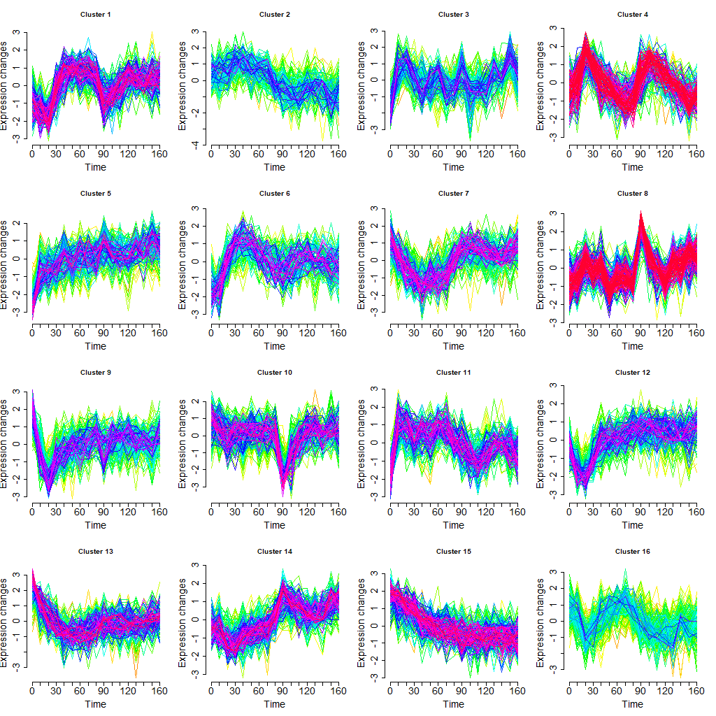

```r
png(filename="images/mfuzz.png", width = 1024, height = 1024)
mfuzz.plot2(yeast.std, cl=yeast.fcm
            , mfrow=c(4,4), time.labels=seq(0,160,10), x11 = FALSE
            , cex.lab=1.8, cex.axis=1.8
)
dev.off()
```

- 列出所有資料的硬分群

可以從所屬分群表中找出每筆資料最有可能的分群結果(即最大機率)，即可以當作硬分群的結果。

```r
# 列出資料於各群的機率
head(yeast.fcm$membership[1:10,])
```

```
##                     1           2            3            4           5
## YDR132C   0.033028690 0.091047608 0.0272342898 0.0072161749 0.009746862
## YMR012W   0.013064433 0.004648061 0.0317682381 0.0128910868 0.136143859
## YLR214W   0.021262985 0.004720011 0.0134056903 0.0012640257 0.016095409
## YLR116W   0.018496989 0.567353910 0.0042186064 0.0045082888 0.002981605
## YDR203W   0.004296047 0.002029703 0.0009991169 0.0008653977 0.001289807
## YEL059C-A 0.003321228 0.021635052 0.0588536312 0.0135463763 0.009529987
##                     6           7            8           9          10
## YDR132C   0.025435025 0.016152389 0.0024919454 0.048377884 0.384844328
## YMR012W   0.011935139 0.083921713 0.1763958042 0.031640131 0.003557096
## YLR214W   0.003750679 0.181247689 0.0045603759 0.427298861 0.061071586
## YLR116W   0.036037039 0.001337328 0.0013323348 0.007197925 0.017362038
## YDR203W   0.001102459 0.060562272 0.0005371039 0.838000204 0.015208288
## YEL059C-A 0.004975952 0.098345330 0.0699972732 0.027929787 0.015051983
##                     11          12          13          14          15
## YDR132C   0.0511866317 0.012329002 0.050887226 0.006803118 0.074120930
## YMR012W   0.0086862169 0.104715888 0.009647844 0.349921194 0.002832611
## YLR214W   0.0042315288 0.064867028 0.057617758 0.081616402 0.005741754
## YLR116W   0.0869577573 0.004017206 0.004239055 0.001107516 0.034789363
## YDR203W   0.0006231445 0.016836355 0.030822104 0.008322579 0.003470340
## YEL059C-A 0.0098121426 0.008431723 0.512016985 0.026613941 0.091321025
##                   16
## YDR132C   0.15909790
## YMR012W   0.01823068
## YLR214W   0.05124822
## YLR116W   0.20806304
## YDR203W   0.01503508
## YEL059C-A 0.02861758
```

```r
# 列出前 10 筆的硬分群
yeast.fcm$cluster[1:10]
```

```
##   YDR132C   YMR012W   YLR214W   YLR116W   YDR203W YEL059C-A   YHR046C
##        10        14         9         2         9        13        13
##   YJL053W   YBL021C   YHR034C
##         9         3        16
```

- 繪出單一分群結果

```r
png(filename="images/mfuzz_1.png", width = 500, height = 500)
mfuzz.plot2(yeast.std, cl=yeast.fcm
            , mfrow=c(1,1), time.labels=seq(0,160,10), x11 = FALSE
            , cex.lab=1.8, cex.axis=1.8, single = 1
)
```

```r
dev.off()
```

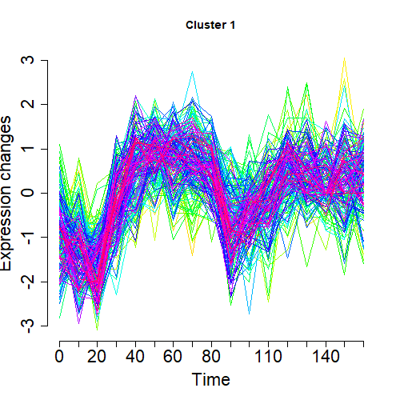